# Practice 12

Elena Tuzhilina

April 4, 2023

### Question 1

You are given information about 15 Titanic passengers.

|  | PassengerId | Sex | Age | Class | Survived |
| --- | --- | --- | --- | --- | --- |
| 773 | 773 | female | 57 | 2 | no |
| 698 | 698 | female | NA | 3 | yes |
| 652 | 652 | female | 18 | 2 | yes |
| 548 | 548 | male | NA | 2 | yes |
| 890 | 890 | male | 26 | 1 | yes |
| 875 | 875 | female | 28 | 2 | yes |
| 392 | 392 | male | 21 | 3 | yes |
| 788 | 788 | male | 8 | 3 | no |
| 330 | 330 | female | 16 | 1 | yes |
| 183 | 183 | male | 9 | 3 | no |
| 680 | 680 | male | 36 | 1 | yes |
| 560 | 560 | female | 36 | 3 | yes |
| 104 | 104 | male | 33 | 3 | no |
| 136 | 136 | male | 23 | 2 | no |
| 37 | 37 | male | NA | 3 | yes |

1. Compute the contingency table for Sex and Class variables.

| female | male |
| --- | --- |
| 1 | 2 |
| 3 | 2 |
| 2 | 5 |

2. Compute marginal frequencies for Sex and Class variables.

|  | female | male | Sum |
| --- | --- | --- | --- |
| 1 | 1 | 2 | 3 |
| 2 | 3 | 2 | 5 |
| 3 | 2 | 5 | 7 |
| Sum | 6 | 9 | 15 |

3. Compute joint probabilities for P(Sex = …, Class = …). Six probabilities in total.

| Sex | Class | Frequency | Joint_Probability |
| --- | --- | --- | --- |
| female | 1 | 1 | 0.0666667 |
| female | 2 | 3 | 0.2000000 |
| female | 3 | 2 | 0.1333333 |
| male | 1 | 2 | 0.1333333 |
| male | 2 | 2 | 0.1333333 |
| male | 3 | 5 | 0.3333333 |

4. Compute joint probabilities for P(Class = …|Sex = …). Six probabilities in total.

| Sex | Class | Frequency | Joint_Probability | Conditional_Probability |
| --- | --- | --- | --- | --- |
| female | 1 | 1 | 0.0666667 | 0.1666667 |
| female | 2 | 3 | 0.2000000 | 0.5000000 |
| female | 3 | 2 | 0.1333333 | 0.3333333 |
| male | 1 | 2 | 0.1333333 | 0.2222222 |
| male | 2 | 2 | 0.1333333 | 0.2222222 |
| male | 3 | 5 | 0.3333333 | 0.5555556 |

5. Draw a stacked barplot. Do you think there is an association between these two variables?

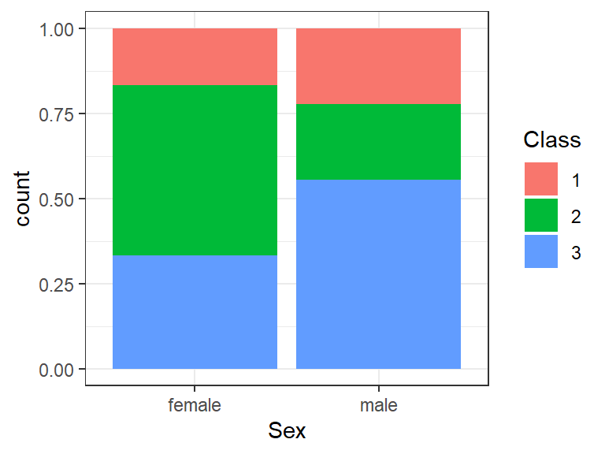

Looks like there is an association.

### Question 2

You are given Sex vs Class contingency table for all Titanic passengers, and you want to test these two variables for the independence.

```r
tab = table(data$Class, data$Sex)
kable(tab)
```

| female | male |
| --- | --- |
| 94 | 122 |
| 76 | 108 |
| 144 | 347 |

1. State $H_0$ and $H_a$.

$H_0:$ Sex and Class are independent.

$H_a:$ Sex and Class are dependent.

2. Find expected and observed counts for this table.

| Sex | Class | Observed | Expected |
| --- | --- | --- | --- |
| female | 1 | 94 | 76.12121 |
| female | 2 | 76 | 64.84400 |
| female | 3 | 144 | 173.03479 |
| male | 1 | 122 | 139.87879 |
| male | 2 | 108 | 119.15600 |
| male | 3 | 347 | 317.96521 |

3. Find the test statistic.

$\chi_{obs}^2 = 16.971$

4. Find the p-value.

We use $df = (2-1)(3-1) = 2$. From the table, *p-value* < 0.01.

5. Draw the conclusion at significance level $0.01$.

Since *p-value* < 0.01, we can reject null and conclude that Sex and Class variables are dependent.

```r
chisq.test(x = data$Sex, y = data$Class, correct = F)
```

```
##
##  Pearson's Chi-squared test
##
## data:  data$Sex and data$Class
## X-squared = 16.971, df = 2, p-value = 0.0002064
```

# Question 3

The iris data set gives the measurements in centimeters of the variables sepal length and width and petal length and width, respectively, for 50 flowers from each of 3 species of iris (150 flowers in total). The species are Iris setosa, versicolor, and virginica.

Here are summary statistics for Sepal and Petal lengths.

```r
mean(Sepal.Length)
```

```
## [1] 5.843333
```

```r
mean(Petal.Length)
```

```
## [1] 3.758
```

```r
sd(Sepal.Length)
```

```
## [1] 0.8280661
```

```r
sd(Petal.Length)
```

```
## [1] 1.765298
```

```r
cor(Sepal.Length, Petal.Length)
```

```
## [1] 0.8717538
```

1. Do you think there is an association between Sepal and Petal lengths?

Probably, as the correlation is positive and close to 1.

2. You want to fit the regression line to the following scatterplot plot.

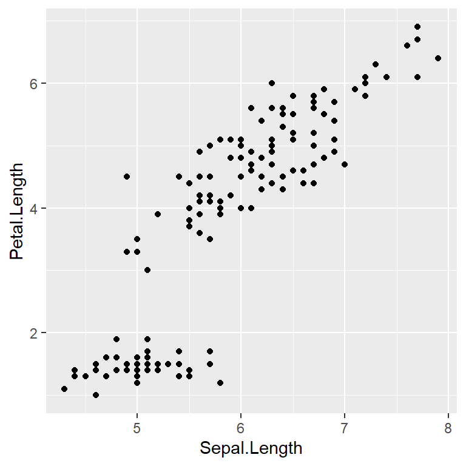

State the regression line equation.

$Petal.Length = a\cdot Sepal.Length+b$

3. Find regression coefficients.

$a = 1.858,~b = -7.101$

4. What is the interpretation of the regression coefficients?

*slope* $a$: if Sepal length increases by one unit, Petal length will increase by 1.858

*intercept* $b$: Petal length is -7.101 for the flowers with zero Sepal length (does not make much sense in this context).

5. Check if point $Sepal.Length = 6$ and $Petal.Length = 3$ lies on the regression line.

The predicted value is $\hat y_i = 1.858 \cdot 6 - 7.101 = 4.047$.

It is not equal to $3$, thus the point does not lie on the regression line.

6. Find the residual for point $Sepal.Length = 6$ and $Petal.Length = 3$. Does this point lie below or above the regression line?

$e_i = y_i - \hat y_i = 3 - 4.047 = -1.047$

The residual is negative, thus the point lies below the line.

7. Check that $Sepal.Length = \bar{x}$ and $Petal.Length = \bar{y}$ point lies on the regression line.

$1.858 \cdot 5.84 - 7.101 = 3.758$

8. Use the regression line to predict the value of Petal length if Sepal length is $6$ and $7$.

$1.858 \cdot 6 - 7.101 = 4.047$

$1.858\cdot 7 - 7.101 = 5.905$

9. Add the regression line to the scatterplot.

The regression line will pass through the points from the previous part.

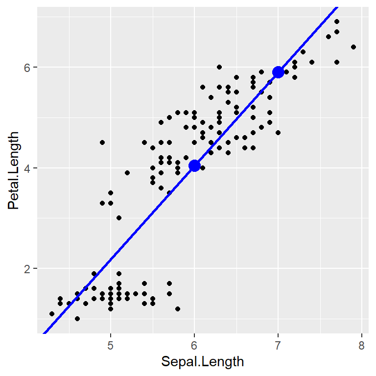

10. Find $TSS$ from the provided information.

From the sample standard deviation we find $TSS = (n-1)\cdot s_y^2 = 149\cdot 1.76^2 = 461.5$

11. Find $R^2$ from the provided information. Do you think linear model fits the data well?

From the sample correlation we find $R^2 = r^2_{xy} = 0.872^2 = 0.76$.

Yes, $R^2$ if close to 1.

12. Find $RSS$ from the provided information.

From $R^2 = 1 - \frac{RSS}{TSS}$ we find $RSS = (1 - R^2)\cdot TSS = (1-0.76)\cdot 461.5 = 111$

13. Find $ESS$ from the provided information.

$ESS = TSS - RSS = 461.5 - 111 = 350.5$

```r
lm(Petal.Length~Sepal.Length)
```

```
##
## Call:
## lm(formula = Petal.Length ~ Sepal.Length)
##
## Coefficients:
##  (Intercept)  Sepal.Length
##       -7.101         1.858
```